# Introduction to statistics

author: Alejandro Cáceres date:  
autosize: true

Barcelona East School of Engineering  
Universitat Politècnica de Catalunya (UPC)

Lecture 8

# Objective

- Interval estimation definition
- Confidence intervals for means
- Confidence intervals for variances
- Confidence intervals for proportions

# Interval estimation

We usually start by performing a random experiment $n$ times

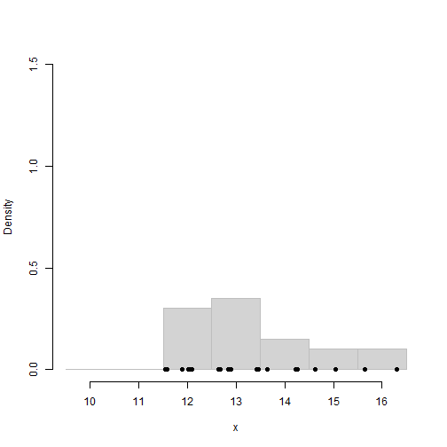

# Interval estimation

We assume that the random experiment follows a distribution $X \hookrightarrow f(X; \theta)$. But which one is it? which parameter $\theta$ ($\mu$ in the case of $N(\mu, \sigma)$) should we choose?

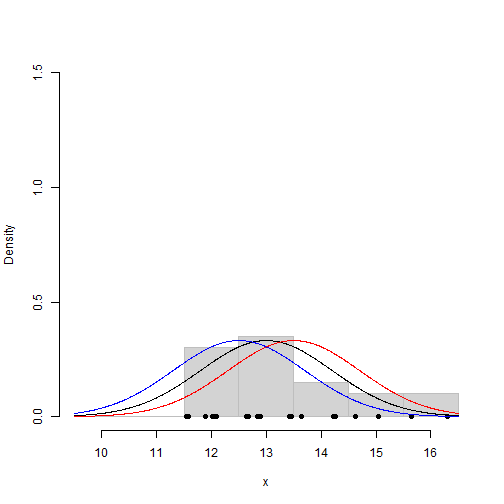

# Interval estimation

When we propose a probability model for the random variable $X \hookrightarrow f(X; \theta)$

- We can use **maximum likelihood** or the **method of moments** to propose estimators $\Theta$ for the parameter $\theta$.
- Estimators are random variables that represent the random experiment of repeating the experiment of $X$ $n$ times and combine the results to compute the estimate $\hat{\theta}$.
- The estimate $\hat{\theta}$ is obtained from the data and is one observed value from the random experiment that measures the estimator $\Theta$.

# Interval estimation

Maximum likelihood and the method of moments tell us that to estimate $\mu$ we **can** choose $\bar{x}$, which is the observation of the random variable $\bar{X}$

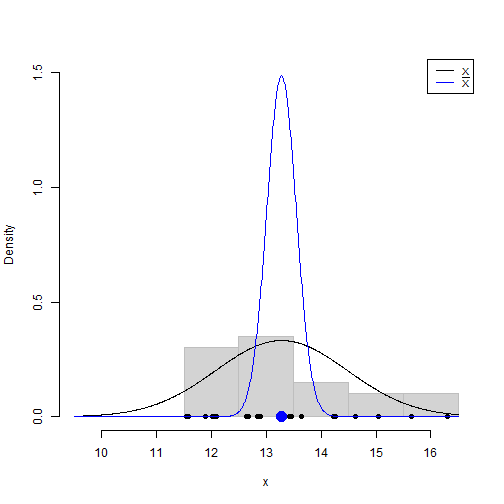

# Interval estimation

How **confident** are we that $\bar{x}$ is close to the **real** $\mu$?

If we repeat the $n$-experiments many times we will get a different answer for $\bar{x}$ each time because $\bar{X}$ is a random variable.

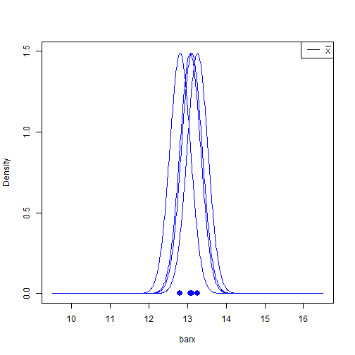

# Interval estimation

Each value of $\bar{x}$ infers a different distribution of $X$

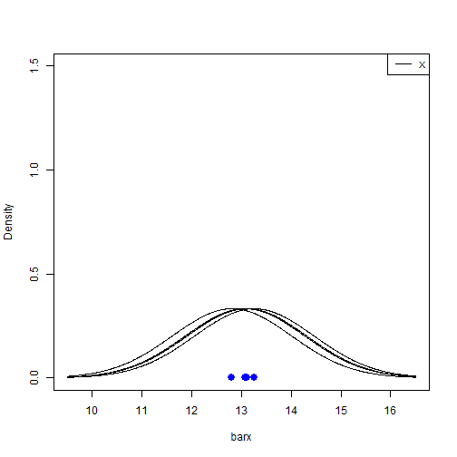

# Interval estimation

We usually have only one value of $\bar{x}$ or repeat the experiment $n$ times only.

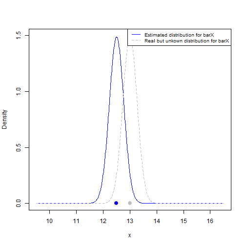

# Interval estimation

Let’s consider the case of the mean $\mu$: When we estimate $\mu \sim \bar{x}$ ($\hat{\mu} = \bar{x}$)

- We don’t know how close we are from the true but unknown value of $\mu$.
- To know how far $\bar{x}$ can fall from $\mu$, we define the limits $(f_{inf}, f_{sup})$ such that we have a $95\%$ probability that the difference between $\bar{x}$ and $\mu$ is between these numbers.

We want to identify the inter-95% range of $\bar{X}$ about the the mean $\mu$.

# Interval estimation

Let’s write it as:

$P(f_{inf} \leq \bar{X} - \mu \leq f_{sup} )=0.95$

$P(\bar{X} - f_{sup} \leq \mu \leq \bar{X} - f_{inf} )=0.95$

which motivates the definition for the **random interval**

- $(L,U)$ such that $P(L \leq \mu \leq U )=0.95$.

When the interval captures the **distance** $(\bar{X}-\mu)$ to the parameter then

$(L,U)=(\bar{X} - f_{sup},\bar{X} - f_{inf})$

This interval is a **random variable** and it has by definition a probability of $0.95$ to contain $\mu$.

# Interval estimation

When we perform $n$-random experiments ($n$-sample) we can calculate $f_{inf}$ y $f_{sup}$.

- the interval that we obtain from the experiment is

$(l,u)=(\bar{x} - f_{sup},\bar{x} - f_{inf})$ (script size)

- this interval either contains or not the parameter $\mu$: we will **never know**!
- We say that we have a confidence of $95\%$ that the interval $(l,u)$ will capture the true unknown parameter $\mu$. Think of buying a lottery ticked for which you do not know the result.

# Interval estimation

- Let’s consider the probability

$P(f_{inf} \leq \bar{X} - \mu \leq f_{sup} )=0.95$

- divide by $\sigma_{\bar{X}}$

$P( \frac{f_{inf}}{\sigma_{\bar{X}}} \leq \frac{\bar{X}-\mu}{\sigma_{\bar{X}}} \leq \frac{f_{sup}}{\sigma_{\bar{X}}} )=0.95$

- Afer substitution by $\sigma_{\bar{X}}=\sigma_{X}/\sqrt{n}$. We then solve:

$P( \frac{f_{inf}}{\sigma_{X}/\sqrt{n}} \leq \frac{\bar{X}-\mu}{\sigma_{X}/\sqrt{n}} \leq \frac{f_{sup}}{\sigma_{X}/\sqrt{n}} )=0.95$

for $f_{inf}$ and $f_{sup}$.

# Interval estimation

We are going to assume two conditions:

1. that $X \hookrightarrow N(\mu, \sigma^2_X)$.
2. that we **know** $\sigma_{X}$ as additional information.

If 1 y 2 are true **then** we can show that $Z=\frac{\bar{X}-\mu}{\sigma_{X}/\sqrt{n}}$ distributes normally $Z \hookrightarrow N(\mu=0, \sigma^2=1)$

- We can use $\Phi^{-1}$ (inverse of the cumulative standard distribution standard ) to find $f_{inf}$ and $f_{sup}$.

# Interval estimation

If we define $z_{0.025}$ and $z_{0.975}$ as the numbers of the standard distribution that capture the 95% of the distribution about the median:

$\Phi^{-1}(0.025)=z_{0.975}$ and $\Phi^{-1}(0.975)=z_{0.025}$

By simmetry: $z_{0.975}=-z_{0.025}$

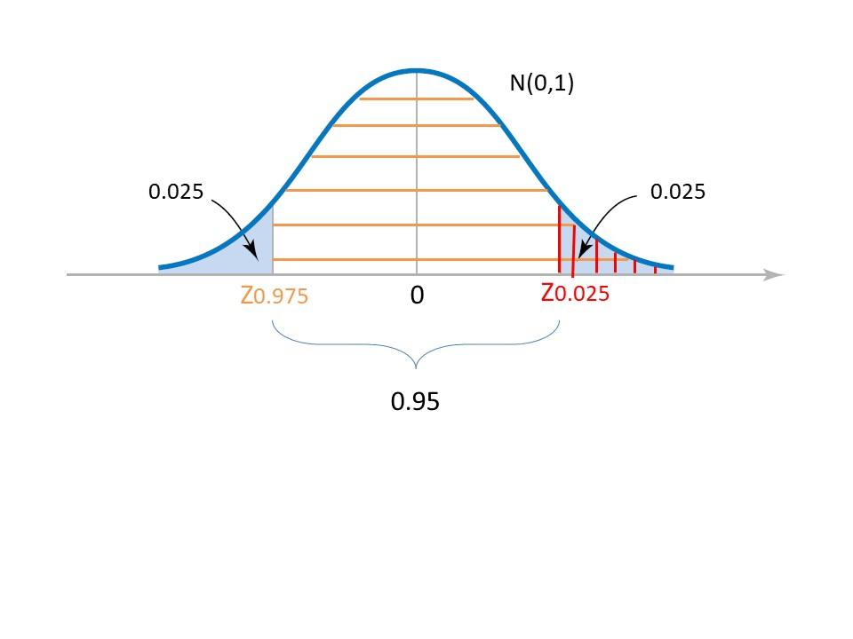

# Interval estimation

then comparing

$P( z_{0.975} \leq Z \leq z_{0.025} )=0.95$

with

$P( \frac{f_{inf}}{\sigma_{X}/\sqrt{n}} \leq \frac{\bar{X}-\mu}{\sigma_{X}/\sqrt{n}} \leq \frac{f_{sup}}{\sigma_{X}/\sqrt{n}} )=0.95$

# Interval estimation

In R we can compute this numbers with the function *qnorm*=$\Phi^{-1}$

```r
z0.975 <- qnorm(0.025)
z0.975
```

```
[1] -1.959964
```

```r
z0.025 <- qnorm(0.975)
z0.025
```

```
[1] 1.959964
```

# Interval estimation

For a randon variable $X$ that distributes normally $X \hookrightarrow N(\mu, \sigma^2_X)$ with know variance $\sigma^2_X$, the $95%$ random interval is

$(L,U) = (\bar{X} - f_{sup},\bar{X} - f_{inf})=$

$(\bar{X} -z_{0.025}\sigma_{X}/\sqrt{n},\bar{X} + z_{0.025} \sigma_{X}/\sqrt{n})$

$(\bar{X} - 1.96\sigma_{X}/\sqrt{n},\bar{X} + 1.96 \sigma_{X}/\sqrt{n})$

and the **observed** $95\%$ confidence interval is

$(l,u) = (\bar{x} - 1.96\sigma_{X}/\sqrt{n},\bar{x} + 1.96\sigma_{X}/\sqrt{n})$

We also write that the estimate of the mean $\mu$

$\hat{\mu}=\bar{x} \pm 1.96\sigma_{X}/\sqrt{n}$

And so we separate signal from error!

note: probability is in $X$, signal in $E(\bar{X})$ and error in $V(\bar{X})$.

# Interval estimation

For a sample of 8 observations, we have one estimate of the mean and one confidence interval

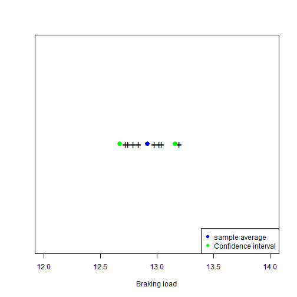

# Interval estimation

Every time that we obtain a new sample then the estimates change. If we perform 100 samples then $95%$ of the confidence intervals will contain $\mu$ (we do not know which!)

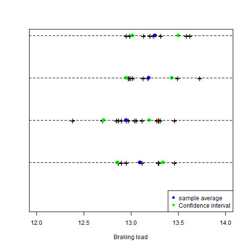

# Interval estimation

From the estimator distribution of $\Theta$ we define a **confidence limit** $\alpha$ such that the probability that the **random interval** $(L,U)$ contains the parameter $\theta$ is $(1-\alpha)$.

$P(L \leq \theta \leq U)=P(\Theta -f_{\alpha/2} \leq \theta \leq \Theta - f_{1-\alpha/2})=1-\alpha$

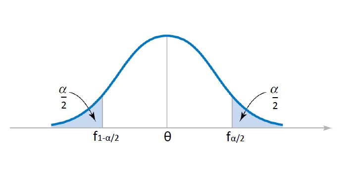

# Interval estimation

If the $95\%$ confidence interval at confidence limit of $0.05%$ (the amount of probability that is left out) for $X \hookrightarrow N(\mu, \sigma_X)$ and known $\sigma_X$ is

$(l,u) = (\bar{x} - z_{0.025}\sigma_{X}/\sqrt{n},\bar{x} - z_{0.975}\sigma_{X}/\sqrt{n})$ by symmety:

$(l,u) = (\bar{x} - z_{0.025}\sigma_{X}/\sqrt{n},\bar{x} +z_{0.025} \sigma_{X}/\sqrt{n})$

Likewise, the $99\%$ confidence interval at confidence limit $0.01$ is

$(l,u) = (\bar{x} - z_{0.005}\sigma_{X}/\sqrt{n},\bar{x} + z_{0.005}\sigma_{X}/\sqrt{n})$

$= (\bar{x} - 2.57\sigma_{X}/\sqrt{n},\bar{x} + 2.57\sigma_{X}/\sqrt{n})$

or

$\hat{\mu}=\bar{x} \pm 2.57\sigma_{X}/\sqrt{n}$

If we want to be more confident then we need larger confidence intervals!

# Interval estimation

You can remember $z_{0.025}=\Phi^{-1}(0.975)=1.96$ or $z_{0.005}=\Phi^{-1}(0.995)=2.57$ if not, use R or look it up on a table.

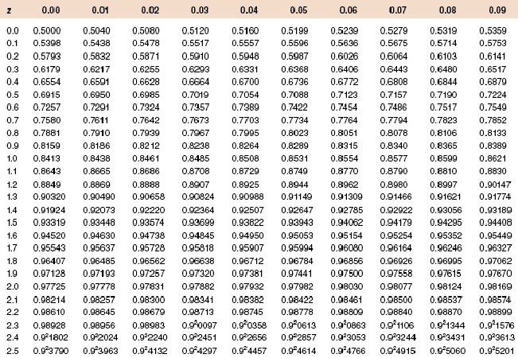

# Interval estimation

Confidence intervals are highly misunderstood!

- A confidence interval is one outcome of a random process
- when we obtain a CI we do not know whether it contains the parameter!
- $1-\alpha$ percent of the times CI intervals contain the parameter
- CI are not probabilities of observing the parameter.

For one set of measurements, we just get a box with a confidence level that contains the parameter … but we can never look inside!

# Interval estimation for the mean

A metallic material is tested for impact to measure the energy required to cut it at a given temperature.

- Ten specimens of A238 steel were cut at 60ºC at the following impact energies (J)
- $64.1, 64.7, 64.5, 64.6, 64.5, 64.3, 64.6, 64.8, 64.2, 64.3$
- If we know that the impact energy is randomly distributed with $\sigma=1J$ what is the $95\%$ CI for the mean of these data?

# Interval estimation for the mean

We know

- $x_i=\{64.1, 64.7, 64.5, 64.6, 64.5, 64.3, 64.6, 64.8, 64.2, 64.3\}$
- $X \rightarrow N(\mu, \sigma^2)$
- $\sigma=1J$
- $\alpha=0.05$

The confidence interval is then

$CI=(\bar{x}-1.96 \frac{\sigma}{\sqrt{n}}, \bar{x}+1.96 \frac{\sigma}{\sqrt{n}})$  
$=(64.46-1.96 \frac{1}{\sqrt{10}}, 64.46+1.96 \frac{1}{\sqrt{10}})=(63.84,65.08)$

or

$\hat{\mu}=64.46 \pm 0.61$

this tells us that we can be sure on the first digit (6), somewhat confident on the second (4) and unsure on the decimals (46).

# Interval estimation for the mean

What is the confidence interval at $1\%$ confidence limit?

We know

- $x_i=\{64.1, 64.7, 64.5, 64.6, 64.5, 64.3, 64.6, 64.8, 64.2, 64.3\}$
- $X \rightarrow N(\mu, \sigma^2)$
- $\sigma=1J$
- $\alpha=0.01$

# Interval estimation for the mean

The $99\%$ confidence interval( or $1\%$ level) is then

$CI_{99\%}=(\bar{x}-2.57 \frac{\sigma}{\sqrt{n}}, \bar{x}+2.57 \frac{\sigma}{\sqrt{n}})$  
$=(64.46-2.57 \frac{1}{\sqrt{10}}, 64.46+2.57 \frac{1}{\sqrt{10}})=(63.64,65.27)$

note that $CI_{95\%}=(63.84,65.08) \subset CI_{99\%}=(63.64,65.27)$

# Interval estimation for the mean (unknown variance)

What if we **don’t know** $\sigma_X$: The most likely situation!

We are going to assume only the condition:

1. that $X \hookrightarrow N(\mu, \sigma^2_X)$.

If we do not know the **variance** we can estimate it by $S^2$ and form the standardized statistic

$T=\frac{\bar{X}-E(\bar{X})}{\sqrt{V(\bar{X})}}= \frac{\bar{X}-\mu}{S/\sqrt{n}}$

# Interval estimation for the mean (unknown variance)

If:

- $n>30$ then the central limit theorem gives us a good approximation to a normal distribution for

$T= \frac{\bar{X}-\mu}{S/\sqrt{n}}\hookrightarrow N(\mu, s^2)$

- $n<30$ then $T$ follows a **t** distribution with $n-1$ degrees of freedom.

$T=\frac{\bar{X}-\mu}{S/\sqrt{n}}\hookrightarrow t(n-1)$

# Interval estimation for the mean (unknown variance)

From the definition of random confidence interval at confidence $95\%$

$(L,U) = (\bar{X} - f_{sup},\bar{X} - f_{inf})$, such that $P(\bar{X} - f_{sup} \leq \mu \leq \bar{X} - f_{inf})=0.95$

we have:

$f_{inf}=t_{0.975,n-1}*S/\sqrt{n}$

$f_{sup}=t_{0.025,n-1}*S/\sqrt{n}$

$(l,u) = (\bar{x} - t_{0.025,n-1}s/\sqrt{n},\bar{x} - t_{0.975, n-1}s/\sqrt{n})$ by simmetry of the $t$ distribution:

$(l,u) = (\bar{x} - t_{0.025,n-1}s/\sqrt{n},\bar{x} + t_{0.025, n-1}s/\sqrt{n})$

# Interval estimation for the mean (unknown variance)

or for the $99 \%$ CI we have:

$f_{inf}=t_{0.995,n-1}\cdot S/\sqrt{n}$

$f_{sup}=t_{0.005,n-1}\cdot S/\sqrt{n}$

$(l,u) = (\bar{x} - t_{0.005,n-1}s/\sqrt{n},\bar{x} - t_{0.995, n-1}s/\sqrt{n})$ by simmetry of the $t$ distribution:

$(l,u) = (\bar{x} - t_{0.005,n-1}s/\sqrt{n},\bar{x} + t_{0.005, n-1}s/\sqrt{n})$

# Interval estimation for the mean (unknown variance)

A metallic material is tested for impact to measure the energy required to cut it at a given temperature.

- Ten specimens of A238 steel were cut at 60ºC at the following impact energies (J)
- $64.1, 64.7, 64.5, 64.6, 64.5, 64.3, 64.6, 64.8, 64.2, 64.3$
- If we know that the impact energy is randomly distributed but we **do not know** the variance what is the $95\%$ CI for the mean of these data?